# sem10_MAT2

```python
from matplotlib import ticker
TT = ticker.FormatStrFormatter('%.7f')
import numpy as np
%display latex
```

Ispitajte tok funkcije $f(x)=\dfrac{x+10}{x^2-10x+26}-2.$

```python
f(x)=(x+10)/(x^2-10*x+26)-2
```

### **nultočke** (egzaktne vrijednosti)

```python
nul = solve(f(x)==0,x)
nul
```

\[\newcommand{\Bold}[1]{\mathbf{#1}}\left[x = -\frac{1}{4} \, \sqrt{105} + \frac{21}{4}, x = \frac{1}{4} \, \sqrt{105} + \frac{21}{4}\right]\]

### **nultočke** (numeričke vrijednosti)

```python
list(map(lambda x: n(x.rhs()), nul))
```

\[\newcommand{\Bold}[1]{\mathbf{#1}}\left[2.68826230851010, 7.81173769148990\right]\]

### **derivacija**

```python
der=diff(f(x),x).factor()
der
```

\[\newcommand{\Bold}[1]{\mathbf{#1}}-\frac{x^{2} + 20 \, x - 126}{{\left(x^{2} - 10 \, x + 26\right)}^{2}}\]

### **stacionarne točke** (egzaktne vrijednosti)

```python
stac = solve(der==0,x)
stac
```

\[\newcommand{\Bold}[1]{\mathbf{#1}}\left[x = -\sqrt{226} - 10, x = \sqrt{226} - 10\right]\]

### **stacionarne točke** (numeričke vrijednosti)

```python
stac_num = list(map(lambda x: n(x.rhs()), stac))
stac_num
```

\[\newcommand{\Bold}[1]{\mathbf{#1}}\left[-25.0332963783729, 5.03329637837291\right]\]

### **druga derivacija**

```python
der2 = diff(f(x),x,2)
der2.factor()
```

\[\newcommand{\Bold}[1]{\mathbf{#1}}\frac{2 \, {\left(x^{3} + 30 \, x^{2} - 378 \, x + 1000\right)}}{{\left(x^{2} - 10 \, x + 26\right)}^{3}}\]

**ispitivanje karaktera stacionarnih točaka pomoću druge derivacije**

```python
list(map(lambda t: der2.subs(x=t), stac_num))
```

\[\newcommand{\Bold}[1]{\mathbf{#1}}\left[0.0000368731110213056, -30.0000368731112\right]\]

**pripadne točke lokalnog minimuma i lokalnog maksimuma na grafu funkcije**

```python
list(map(lambda t: (t, f(t)), stac_num))
```

\[\newcommand{\Bold}[1]{\mathbf{#1}}\left[\left(-25.0332963783729, -2.01664818918645\right), \left(5.03329637837291, 13.0166481891865\right)\right]\]

### **točke infleksije** - treba numerički riješiti jednadžbu $f''(x)=0$

Na većoj domeni uočavamo sa slike dvije nultočke od $f''$

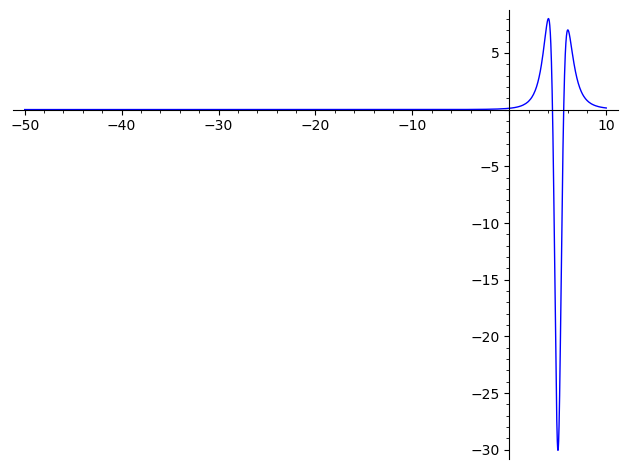

```python
plot(der2,x,-50,10)
```

Zumiramo sliku na manji dio domene od $f''$ gdje smo uočili nultočke

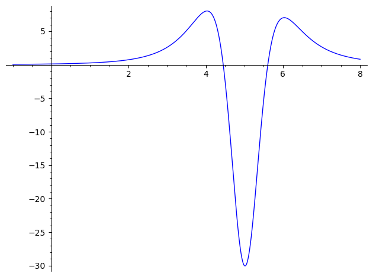

```python
plot(der2,x,-1,8)
```

sa zumirane slike vidimo da se nultočke nalaze na intervalima $\langle4,5\rangle$ i $\langle5,6\rangle$

```python
a1 = find_root(der2,4,5)
a1
```

\[\newcommand{\Bold}[1]{\mathbf{#1}}4.451866084468802\]

```python
a2 = find_root(der2,5,6)
a2
```

\[\newcommand{\Bold}[1]{\mathbf{#1}}5.607325047828771\]

Međutim, $f''$ ima još jednu nultočku koju tek jasno vidimo ako zumiramo sliku na dio domene oko broja $-40$.  
Uočite kako $f''$ poprima jako male vrijednosti na segmentu $[-50,-30]$ zbog čega je bilo teško uočiti njezinu treću nultočke sa slike koja pokriva veći dio domene.

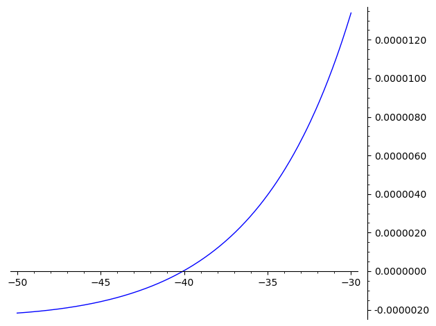

```python
plot(der2,x,-50,-30,tick_formatter=[None,TT])
```

```python
a3 = find_root(der2,-45,-35)
a3
```

\[\newcommand{\Bold}[1]{\mathbf{#1}}-40.05919113229758\]

**točke infleksije na grafu funkcije $f$**

```python
infleksije = list(map(lambda t: (t, f(t)), [a1,a2,a3]))
infleksije
```

\[\newcommand{\Bold}[1]{\mathbf{#1}}\left[\left(4.451866084468802, 9.112966521117174\right), \left(5.607325047828771, 9.401831261957176\right), \left(-40.05919113229758, -2.014797783074393\right)\right]\]

Nultočke od $f''$ svode se na traženje nultočaka polinoma $x^3+30x^2-378x+1000$.  
Postoje numerički algoritmi koji mogu dati sve nultočke zadanog polinoma bez da moramo crtati sliku.  
Takav algoritam je implementiran u python numpy modulu.

```python
np.roots([1, 30, -378, 1000])
```

\[\newcommand{\Bold}[1]{\mathbf{#1}}\verb|[-40.05919113|\verb| |\verb|5.60732505|\verb| |\verb|4.45186608]|\]

Također, u SageMath alatu klasa koja reprezentira polinome ima metodu `roots` koja daje sve nultočke polinoma u nekom polju (u ovom slučaju nas zanimaju samo realne nultočke).

```python
R.<t>=QQ[]
p = t^3 + 30*t^2 -378*t + 1000
p.roots(RR)
```

\[\newcommand{\Bold}[1]{\mathbf{#1}}\left[\left(-40.0591911322976, 1\right), \left(4.45186608446880, 1\right), \left(5.60732504782877, 1\right)\right]\]

**Graf funkcije $f$**

- Pazite, funkcija $f$ oko lokalnog minimuma jako sporo mijenja vrijednosti i na velikoj slici se to uopće ne primijeti, čak bismo rekli na temelju slike da lokalni minimum uopće ne postoji.
- Pazite, funkcija $f$ na segmentu $[-90,-20]$ jako sporo mijenja vrijednosti zbog čega je na većoj slici jako teško uočljiva točka infleksije $-40.059$.
- Međutim, ako sliku zumiramo oko lokalnog minimuma (manja slika), tada vidimo da lokalni minimum zaista postoji. Primijetite kako funkcija jako sporo pada i raste u okolini lokalnog minimuma.
- Također, na drugoj manjoj slici gdje crtamo funkciju $f$ na segmentu $[-90,-20]$ možemo uočiti da na tom segmentu postoji točka infleksije.
- Ovaj primjer pokazuje kako su diferencijalni račun i teorija jako bitni jer oni pokazuju da lokalni minimum zaista postoji te da zaista postoje tri točke infleksije, iako na (velikoj) slici teško možemo sve to uočiti.

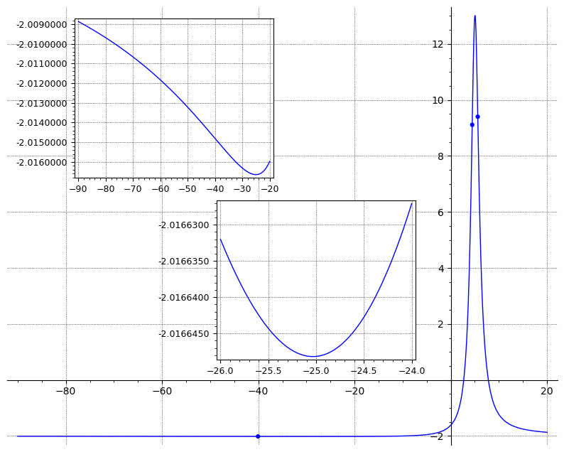

```python
slika1 = plot(f(x),(x,-90,20),gridlines=True) + point(infleksije, size=20)
slika2 = plot(f(x),(x,-26,-24),gridlines=True,frame=True,tick_formatter=[None,TT],fontsize=9)
slika3 = plot(f(x),(x,-90,-20),gridlines=True,frame=True,tick_formatter=[None,TT],fontsize=9)
slika = multi_graphics([slika1, (slika2, (0.42, 0.26, 0.28, 0.28)), (slika3, (0.22, 0.58, 0.28, 0.28))])
slika.show(figsize=[10,8])
```

spremanje slike u tekući direktorij u *png* format željene kvalitete i dimenzija

```python
slika.save("fun1.png", figsize=[10,8], dpi=300)
```